26 November 2026

# Spain votes again

The road to the 29 November general election  
**Isabela Zeberio** · Universiteit van Amsterdam

Photo: Puerta del Sol camp, 2026 — Raystorm, Wikimedia Commons (CC BY-SA 4.0)

Part 1

# How Spaniards vote

A ballot for a party, not a person, and more elections than planned.

01

How Spaniards vote

Dictatorship to fragmentation

2023 and the players

The road to the snap election

The debates

1 · The ballot

## The ballot: for Congress you vote for a party list, not a person

ELECCIONES GENERALES 2026  
**CONGRESO DE LOS DIPUTADOS**  
Circunscripción: MADRID

PARTY X

1. Candidate 1
2. Candidate 2
3. Candidate 3
4. Candidate 4
5. Candidate 5
6. Candidate 6
7. Candidate 7
8. …

**Congress**: closed, blocked list. One ballot in the envelope; the order of names can’t be changed.

ELECCIONES GENERALES 2026  
**SENADO**  
Mark up to 3

Party X

Candidate X1

Candidate X2

Candidate X3

Party Y

Candidate Y1

Candidate Y2

Candidate Y3

Party Z

Candidate Z1

Candidate Z2

Candidate Z3

**Senate**: open ballot. Tick up to 3 names, even from different parties.

### 52 districts

One per province + Ceuta and Melilla. D’Hondt, 3% threshold per district. Small provinces elect only 2–4 MPs.

NL

One national list per party, but you vote for **a candidate** (preference vote). One national district, no formal threshold.

Source: Ley Orgánica 5/1985 del Régimen Electoral General (LOREG); Ministry of the Interior; Kiesraad. Ballots shown are schematic.

1 · Meanwhile in the Netherlands

## …while the Dutch ballot lists every candidate of every party

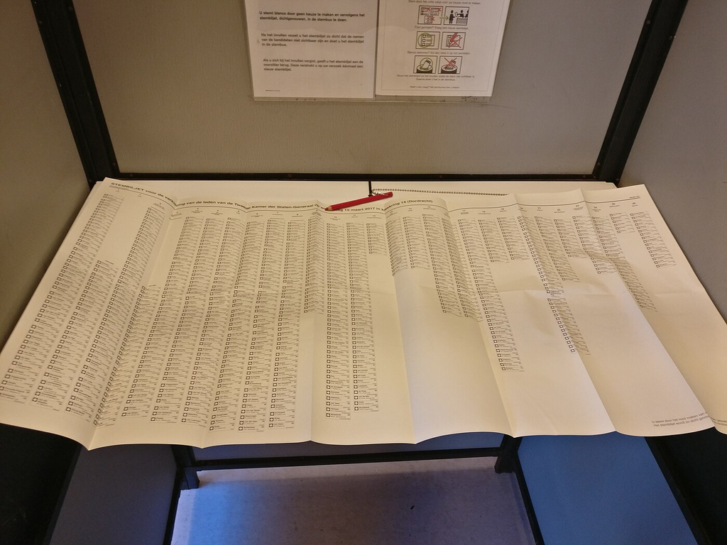

37

party lists on the 2021 Tweede Kamer ballot

### “I could use it as…”

Source: Kiesraad (2021 Tweede Kamer election); r/europe, ‘The huge Dutch election ballot’ (2021).

Photo: Dutch ballot, 2017 general election — 1Veertje, Wikimedia Commons (CC BY-SA 3.0).

1 · Elections

## Spaniards vote often, and lately more often than planned

**General**At least every 4 years; can be called earlyNext: 29 Nov 2026

**Regional (17 regions)**Every 4 years; most with the municipal vote, some on their own datesNext: May 2027 (most)

**Municipal**Fixed: 4th Sunday of May, every 4 yearsNext: May 2027

**European Parliament**Every 5 yearsNext: 2029

General elections since 1977 · the last six in eleven years

1977

1979

1982

1986

1989

1993

1996

2000

2004

2008

2011

2015

2016

2019 Apr

2019 Nov

2023

2026

Source: Ministry of the Interior, historical election results; LOREG.

Part 2

# From dictatorship to fragmentation

A young democracy, thirty years of alternation, then the 2011 earthquake.

02

How Spaniards vote

Dictatorship to fragmentation

2023 and the players

The road to the snap election

The debates

2 · A young democracy

## From dictatorship to democracy in three years

Nov 1975

### Franco dies

End of a 36-year dictatorship

Dec 1976

### Political Reform Act

Approved by referendum: the regime votes itself out

Jun 1977

### First free elections

First democratic vote since 1936

Dec 1978

### Constitution

Approved by referendum; still in force today

Oct 1982

### First alternation

PSOE wins a landslide: democracy consolidated

### Part of the ‘third wave’

Portugal 1974, Greece 1974, Spain 1975–78: the start of Huntington’s third wave of democratisation in Southern Europe.

NL

Universal suffrage since 1919. Spain’s current democracy dates from **1977**.

Source: Huntington, S. P. (1991) The Third Wave: Democratization in the Late Twentieth Century; Congreso de los Diputados; Ministry of the Interior.

2 · The institutions

## A parliamentary monarchy, like the Netherlands: the king reigns, parliament decides

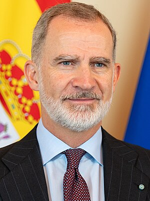

Felipe VI  
King of Spain since 2014

[figure not shown]

Willem-Alexander  
King of the Netherlands since 2013

### A symbolic king

Head of state with no political power: every act is formal and countersigned by the government.

### Congress decides

350 MPs elect the prime minister: **176** votes, or more yes than no in a second vote. The Senate is the weaker chamber.

Source: Spanish Constitution, arts. 56, 64, 66–69 and 99.

Photos: Wikimedia Commons — Saeima (CC BY-SA 2.0); European Union (attribution).

2 · Alternation

## For thirty years, two parties took turns in power, often without a majority

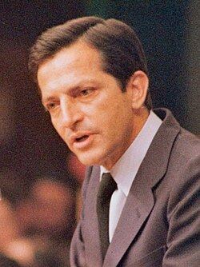

1976–81

**Adolfo Suárez**UCD

**1977** Minority

**1979** Minority

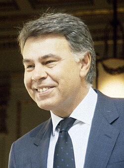

1982–96

**Felipe González**PSOE

**1982** Majority

**1986** Majority

**1989*** Majority

**1993** Minority

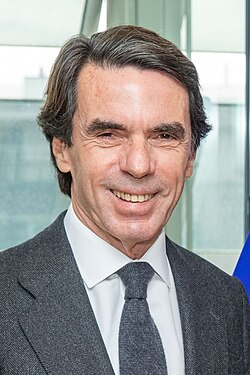

1996–2004

**José María Aznar**PP

**1996** Minority

**2000** Majority

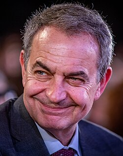

2004–11

**J. L. Rodríguez Zapatero**PSOE

**2004** Minority

**2008** Minority

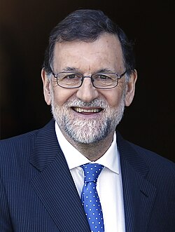

2011–18

**Mariano Rajoy**PP

**2011** Majority

**2015** No government → repeat

**2016** Minority

2018–

**Pedro Sánchez**PSOE

**2018** Minority

**Apr 19** No government → repeat

**Nov 19** Minority coalition

**2023** Minority coalition

Single-party majority = 176+ seats · Minority = governs with outside support · Spain has never had a majority coalition. *1989: 175 seats, a working majority.

Source: La Moncloa; Congreso de los Diputados; Ministry of the Interior (seats per election).

Photos: Wikimedia Commons — Ministerio de la Presidencia (PD / attribution); X. Lejeune (CC BY 4.0); Ministerio de Cultura de la Nación (CC BY-SA 2.0); D. Crespo; Pool Moncloa.

2 · 15-M

## 2011: the crisis and the 15-M ‘indignados’ broke the consensus

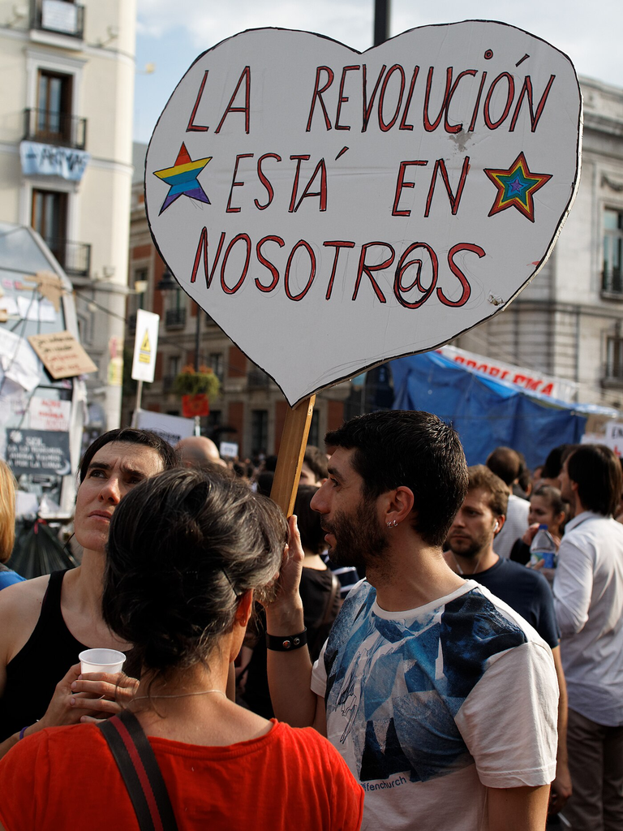

~46%

youth unemployment (under 25) in 2011

15 May 2011

Thousands camp in Madrid’s Puerta del Sol for weeks; the protest spreads across Spain.

### “No nos representan”

“They don’t represent us”: the slogan aimed at both PSOE and PP.

Source: Eurostat, youth unemployment rate (une_rt_a), Spain 2011; El País, RTVE archives (May 2011).

Photo: Puerta del Sol, 2011 — Barcex, Wikimedia Commons (CC BY-SA 3.0).

2 · New challengers

## Each crisis produced a new party: Podemos and Ciudadanos, then Vox

**Economic crisis** → Podemos (left) and Ciudadanos (centre-right, anti-corruption, anti-independence) · **Catalan crisis** → Vox (far right)

WhenWhat happened · seats won (of 350)Who governed

**May 2014**European election

**Podemos** is founded in January and wins 5 MEPs in May

**Rajoy (PP) still governs** Majority

**Dec 2015**General election

Podemos and **Ciudadanos** break the two-party system

PP 123 PSOE 90 Podemos 69 Cs 40

**Nobody wins an investiture** No government → repeat

**Jun 2016**Repeat election

Spain votes again, six months later

PP 137 PSOE 85 UP 71 Cs 32

**Rajoy (PP), Oct 2016** Minority

**Jun 2018**No-confidence vote

A court rules on PP corruption (Gürtel); Sánchez ousts Rajoy

**Sánchez (PSOE), 84 seats** Minority

**Apr 2019**General election

**Vox** enters Congress after the Catalan crisis

PSOE 123 PP 66 Cs 57 UP 42 Vox 24

**No PSOE–UP deal** No government → repeat

**Nov 2019**Repeat election

Vox doubles; Ciudadanos collapses

PSOE 120 PP 89 Vox 52 UP 35 Cs 10

**PSOE + UP, Jan 2020: the first coalition** Minority coalition

Source: Ministry of the Interior, election results 2014–2019; Congreso de los Diputados (investitures and no-confidence vote).

2 · Fragmentation

Source: Ministry of the Interior via Wikipedia, ‘Elections in Spain’ (Congress vote shares 1977–2023). Two largest parties: UCD + PSOE until 1979, PSOE + PP (AP) from 1982.

Part 3

# The last election and the players

July 2023, the 179, and who is on the ballot now.

03

How Spaniards vote

Dictatorship to fragmentation

2023 and the players

The road to the snap election

The debates

3 · July 2023

## The PP came first in 2023, but Sánchez found more partners

[figure not shown]

179

29 Sep 2023

**Feijóo fails**: 172 votes (PP, Vox, UPN, CC)

16 Nov 2023

**Sánchez invested** with 179: PSOE, Sumar + six regional and left partners

### The price

Amnesty for the 2017 Catalan independence leaders

PP 137PSOE 121Vox 33Sumar 31ERC 7Junts 7EH Bildu 6PNV 5BNG 1CC 1UPN 1

Source: Ministry of the Interior, 23-J 2023 results; Congreso de los Diputados, investiture votes of 29 Sep and 16 Nov 2023; LO 1/2024 (amnesty).

3 · Flashback

## October 2017: Catalan independence lasted about a minute

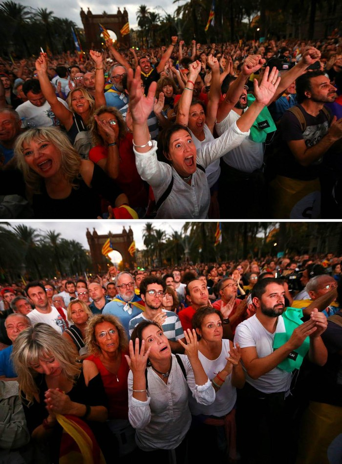

1 Oct 2017

**Referendum**, banned by the Constitutional Court; police charges at polling stations

10 Oct 2017

**Puigdemont declares independence**, and suspends it in the same speech

27 Oct 2017

**Parliament votes it; Madrid imposes direct rule** (Article 155). Leaders jailed; Puigdemont leaves for Belgium

2019 → 2024

**Prison sentences of up to 13 years**, pardons in 2021, amnesty in 2024

**Puigdemont announces his return**, after nine years

Source: Supreme Court ruling 459/2019; El País, BBC (Oct 2017); LO 1/2024; La Nación, El Boletín (Nov 2026). Photo: Reuters / Ivan Alvarado (10 Oct 2017), via Reddit.

3 · The players

## Two axes, not one: left–right and the territorial question

[figure not shown]

3 · The players

## The big three

[figure not shown]

[figure not shown]

PP

Alberto Núñez Feijóo, party president

Centre-right, conservative. Most seats in 2023; wants to govern alone.

“El cambio necesario”

[figure not shown]

PSOE

Pedro Sánchez, PM and party leader

Centre-left, social democrat. In government since 2018.

“La fuerza de la gente”

[figure not shown]

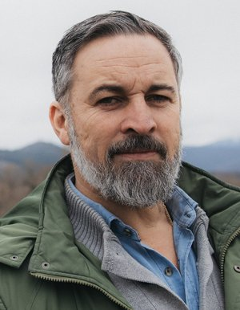

Vox

Santiago Abascal, party president

Far right, nationalist. ‘National priority’, deregulation, ‘remigration’.

“Es sentido común”

Source: Posters via 29n.voto (Nov 2026).

Portraits: Wikimedia Commons — Pool Moncloa/Carlos Spottorno (attribution); Partido Popular (CC0); Vox España (CC0).

3 · The players

## To the left of the PSOE: two lists competing for the same voters

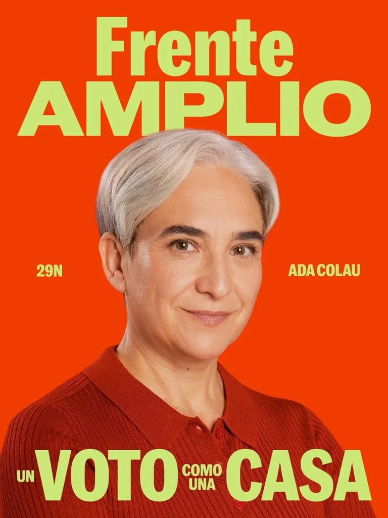

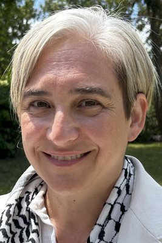

Frente Amplio

Ada Colau, lead candidate (ex-mayor of Barcelona)

Left; successor of Sumar with IU, Más Madrid and Comuns. Housing first.

“Un voto como una casa”

[figure not shown]

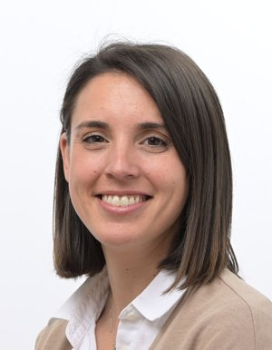

Podemos

Irene Montero, lead candidate

Radical left; runs alone, and with ERC in Catalonia.

“Paz, casa y trabajo”

### Why it matters

In small districts a split vote can elect nobody. Both posters put **housing** at the centre.

Source: Posters via 29n.voto; Público, infoLibre (Oct 2026).

Portraits: Wikimedia Commons — Robo71/Impru20 (CC0); European Parliament.

3 · The players

## The kingmakers: small regional parties that decide majorities

[figure not shown]

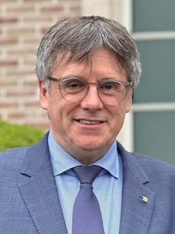

Junts

Carles Puigdemont, president · candidate Míriam Nogueras

Catalan centre-right, independentist

“Catalunya al centre”

[figure not shown]

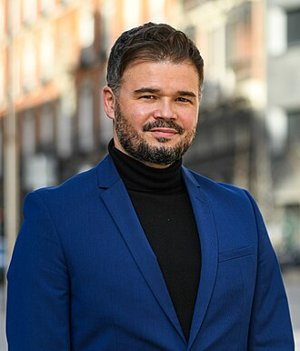

ERC

Gabriel Rufián, candidate · Oriol Junqueras, president

Catalan left, independentist

“Defensa’t”

[figure not shown]

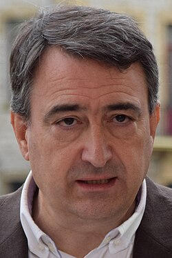

PNV

Aitor Esteban, party president

Basque centre-right, nationalist

“Defendemos Euskadi · Zaindu”

[figure not shown]

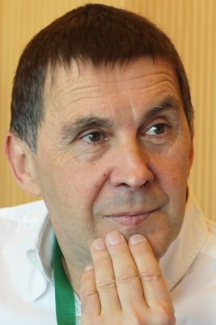

EH Bildu

Arnaldo Otegi, general coordinator

Basque left, independentist

“Posible egin”

Also on the ballot: BNG (Galician left), Coalición Canaria, UPN (Navarre), and in Catalonia the far-right independentist Aliança Catalana.

Source: Posters via 29n.voto (Nov 2026).

Portraits: Wikimedia Commons — Parlament de Catalunya; Marcpuigperez (CC BY-SA 4.0); EAJ-PNV Gipuzkoa (CC BY-SA 2.0); Sinn Féin (CC BY 2.0).

Part 4

# The road to the snap election

From losing the majority to a campaign in mourning.

04

How Spaniards vote

Dictatorship to fragmentation

2023 and the players

The road to the snap election

The debates

4 · Losing the majority

## First the government lost its majority, then one shock followed another

12 Jun 2025

### Cerdán resigns

PSOE no. 3, over a police corruption report

27 Oct 2025

### Junts breaks with the PSOE

The government loses its majority in Congress

18 Jan 2026

### Adamuz rail crash

Two high-speed trains; 45+ dead

22 Jun 2026

### Ábalos gets 24 years

Ex-transport minister convicted

30 Jul 2026

### Ceuta crisis

Mass entry of migrants over two nights

Source: Cerdán: Euronews, Ara, RTVC; Junts: Ara; Adamuz: CIAF via Infobae, Xataka, RTVC; Ábalos: Poder Judicial, Euronews, eldiario.es; Ceuta: Real Instituto Elcano, Euronews.

4 · The trigger

## An eviction made housing the trigger of the election

23 Sep

### Maricarmen evicted

87 years old, after ~70 years in her flat in Retiro, Madrid

26 Sep

### March from Sol to Congress

And a protest camp in Sol; the government drafts housing decrees

2 Oct

### Decrees defeated

178–172: PP, Vox, Junts and UPN vote no

5 Oct

### Snap election called

Sánchez had promised to wait until 2027

7 Oct

### Maricarmen dies

In hospital, before she could return home

**12 Nov, hours before the campaign:** the anti-eviction ‘Maricarmen decree’ is rescued 35–34 in the Diputación Permanente, the committee that sits while parliament is dissolved.

Source: Ara, Euronews, Diario de León (23–26 Sep 2026); El Salto, Ara (2 Oct); Articulo14 (5 Oct); Primicias (7 Oct); Euronews, Ara, Law & Trends (12 Nov 2026).

4 · The streets

## Fifteen years after the 15-M, the tents came back to Puerta del Sol

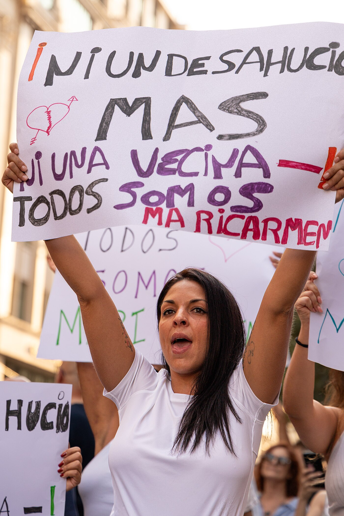

**26 Sep** · “Not one more eviction. We are all Maricarmen”

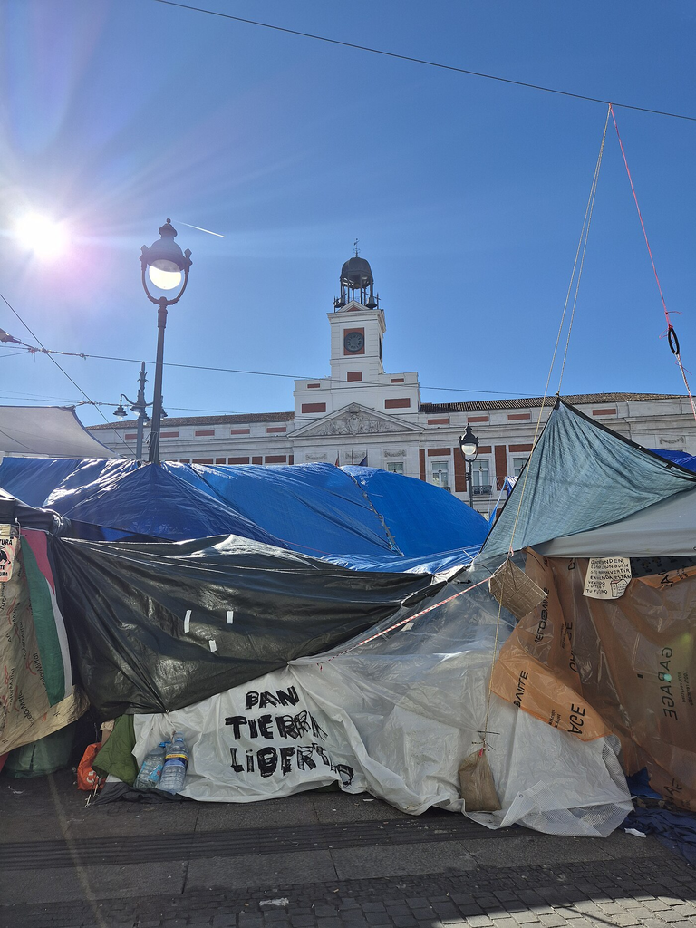

**October** · The housing camp in Sol, in front of the same clock as 2011

[figure not shown]

**10 Oct** · An altar for Maricarmen in the camp

Source: El Salto (11 Nov 2026); Euronews (27 Sep, 15 Oct 2026).

Photos: Wikimedia Commons — Barcex; Raystorm; MiguelAlanCS (all CC BY-SA 4.0).

4 · Accountability